# Computer Assignment 0

Negar Moradi 810198543

## Introduction

#### در این پروژه می خواهیم نواقص یک دیتا را با استفاده از تحلیل های آماری کامل کنیم

## بخش اول

```python
import pandas as pd
DataF = pd.read_csv('FuelConsumptionCo2.csv')
```

#### ذخیره میکنیم DataFrame داده ها را در یک read_csv() با استفاده از تابع

### head() function

```python
DataF.head()
```

|  | Unnamed: 0 | MODELYEAR | MAKE | MODEL | VEHICLECLASS | ENGINESIZE | CYLINDERS | TRANSMISSION | FUELTYPE | FUELCONSUMPTION_CITY | FUELCONSUMPTION_HWY | FUELCONSUMPTION_COMB | FUELCONSUMPTION_COMB_MPG | CO2EMISSIONS |
| --- | --- | --- | --- | --- | --- | --- | --- | --- | --- | --- | --- | --- | --- | --- |
| 0 | 0 | 2014 | ACURA | ILX | COMPACT | 2.0 | 4.0 | AS5 | Z | 9.9 | 6.7 | 8.5 | 33 | 196.0 |
| 1 | 1 | 2014 | ACURA | ILX | COMPACT | 2.4 | 4.0 | M6 | Z | 11.2 | 7.7 | 9.6 | 29 | 221.0 |
| 2 | 2 | 2014 | ACURA | ILX HYBRID | COMPACT | 1.5 | 4.0 | AV7 | Z | 6.0 | 5.8 | 5.9 | 48 | 136.0 |
| 3 | 3 | 2014 | ACURA | MDX 4WD | SUV - SMALL | 3.5 | 6.0 | AS6 | Z | 12.7 | 9.1 | 11.1 | 25 | NaN |
| 4 | 4 | 2014 | ACURA | RDX AWD | SUV - SMALL | 3.5 | 6.0 | AS6 | Z | 12.1 | 8.7 | 10.6 | 27 | 244.0 |

#### با استفاده از این تابع می توانیم به تعداد دلخواه از ابتدای داده را نشان دهیم. این تابع آرگومان دارد و آرگومان آن نشان دهنده ی تعداد ردیف های دیتا از ابتدای آن است. مثالی از آن را در زیر مشاهد میکنید

```python
DataF.head(3)
```

|  | Unnamed: 0 | MODELYEAR | MAKE | MODEL | VEHICLECLASS | ENGINESIZE | CYLINDERS | TRANSMISSION | FUELTYPE | FUELCONSUMPTION_CITY | FUELCONSUMPTION_HWY | FUELCONSUMPTION_COMB | FUELCONSUMPTION_COMB_MPG | CO2EMISSIONS |
| --- | --- | --- | --- | --- | --- | --- | --- | --- | --- | --- | --- | --- | --- | --- |
| 0 | 0 | 2014 | ACURA | ILX | COMPACT | 2.0 | 4.0 | AS5 | Z | 9.9 | 6.7 | 8.5 | 33 | 196.0 |
| 1 | 1 | 2014 | ACURA | ILX | COMPACT | 2.4 | 4.0 | M6 | Z | 11.2 | 7.7 | 9.6 | 29 | 221.0 |
| 2 | 2 | 2014 | ACURA | ILX HYBRID | COMPACT | 1.5 | 4.0 | AV7 | Z | 6.0 | 5.8 | 5.9 | 48 | 136.0 |

#### به طور پیش فرض آرگومان برابر 5 است و همانطور که میبینید در قسمت اول 5 ردیف از ابتدای دیتا نشان داده شد و در قسمت بعد که آرگومان را 3 قرار دادیم 3 ردیف اول نشان داده شد.

### tail() function

```python
DataF.tail()
```

|  | Unnamed: 0 | MODELYEAR | MAKE | MODEL | VEHICLECLASS | ENGINESIZE | CYLINDERS | TRANSMISSION | FUELTYPE | FUELCONSUMPTION_CITY | FUELCONSUMPTION_HWY | FUELCONSUMPTION_COMB | FUELCONSUMPTION_COMB_MPG | CO2EMISSIONS |
| --- | --- | --- | --- | --- | --- | --- | --- | --- | --- | --- | --- | --- | --- | --- |
| 1062 | 1062 | 2014 | VOLVO | XC60 AWD | SUV - SMALL | 3.0 | 6.0 | AS6 | X | 13.4 | 9.8 | 11.8 | 24 | 271.0 |
| 1063 | 1063 | 2014 | VOLVO | XC60 AWD | SUV - SMALL | 3.2 | 6.0 | AS6 | X | 13.2 | 9.5 | 11.5 | 25 | 264.0 |
| 1064 | 1064 | 2014 | VOLVO | XC70 AWD | SUV - SMALL | 3.0 | 6.0 | AS6 | X | 13.4 | 9.8 | 11.8 | 24 | 271.0 |
| 1065 | 1065 | 2014 | VOLVO | XC70 AWD | SUV - SMALL | 3.2 | 6.0 | AS6 | X | 12.9 | 9.3 | 11.3 | 25 | 260.0 |
| 1066 | 1066 | 2014 | VOLVO | XC90 AWD | SUV - STANDARD | 3.2 | 6.0 | AS6 | X | 14.9 | 10.2 | 12.8 | 22 | 294.0 |

#### با استفاده از این تابع می توانیم به تعداد دلخواه از انتهای داده را نشان دهیم. این تابع آرگومان دارد و آرگومان آن نشان دهنده ی تعداد ردیف های دیتا از انتهای آن است. مثالی از آن را در زیر مشاهد میکنید

```python
DataF.tail(4)
```

|  | Unnamed: 0 | MODELYEAR | MAKE | MODEL | VEHICLECLASS | ENGINESIZE | CYLINDERS | TRANSMISSION | FUELTYPE | FUELCONSUMPTION_CITY | FUELCONSUMPTION_HWY | FUELCONSUMPTION_COMB | FUELCONSUMPTION_COMB_MPG | CO2EMISSIONS |
| --- | --- | --- | --- | --- | --- | --- | --- | --- | --- | --- | --- | --- | --- | --- |
| 1063 | 1063 | 2014 | VOLVO | XC60 AWD | SUV - SMALL | 3.2 | 6.0 | AS6 | X | 13.2 | 9.5 | 11.5 | 25 | 264.0 |
| 1064 | 1064 | 2014 | VOLVO | XC70 AWD | SUV - SMALL | 3.0 | 6.0 | AS6 | X | 13.4 | 9.8 | 11.8 | 24 | 271.0 |
| 1065 | 1065 | 2014 | VOLVO | XC70 AWD | SUV - SMALL | 3.2 | 6.0 | AS6 | X | 12.9 | 9.3 | 11.3 | 25 | 260.0 |
| 1066 | 1066 | 2014 | VOLVO | XC90 AWD | SUV - STANDARD | 3.2 | 6.0 | AS6 | X | 14.9 | 10.2 | 12.8 | 22 | 294.0 |

#### به طور پیش فرض آرگومان برابر 5 است و همانطور که میبینید در قسمت اول 5 ردیف از انتهای دیتا نشان داده شد و در قسمت بعد که آرگومان را 4 قرار دادیم 4 ردیف آخر نشان داده شد.

### describe() function

```python
DataF.describe()
```

|  | Unnamed: 0 | MODELYEAR | ENGINESIZE | CYLINDERS | FUELCONSUMPTION_CITY | FUELCONSUMPTION_HWY | FUELCONSUMPTION_COMB | FUELCONSUMPTION_COMB_MPG | CO2EMISSIONS |
| --- | --- | --- | --- | --- | --- | --- | --- | --- | --- |
| count | 1067.000000 | 1067.0 | 1040.000000 | 1033.000000 | 1067.000000 | 1067.000000 | 1067.000000 | 1067.000000 | 964.000000 |
| mean | 533.000000 | 2014.0 | 3.324038 | 5.797677 | 13.296532 | 9.474602 | 11.580881 | 26.441425 | 256.741701 |
| std | 308.160672 | 0.0 | 1.411400 | 1.807262 | 4.101253 | 2.794510 | 3.485595 | 7.468702 | 63.265308 |
| min | 0.000000 | 2014.0 | 1.000000 | 3.000000 | 4.600000 | 4.900000 | 4.700000 | 11.000000 | 108.000000 |
| 25% | 266.500000 | 2014.0 | 2.000000 | 4.000000 | 10.250000 | 7.500000 | 9.000000 | 21.000000 | 209.000000 |
| 50% | 533.000000 | 2014.0 | 3.300000 | 6.000000 | 12.600000 | 8.800000 | 10.900000 | 26.000000 | 251.000000 |
| 75% | 799.500000 | 2014.0 | 4.200000 | 8.000000 | 15.550000 | 10.850000 | 13.350000 | 31.000000 | 294.000000 |
| max | 1066.000000 | 2014.0 | 8.400000 | 12.000000 | 30.200000 | 20.500000 | 25.800000 | 60.000000 | 437.000000 |

#### این تابع بعضی اطلاعات مثل تعداد، میانگین، انحراف معیار، کوچک ترین مقدار، صدک پایینی، صدک میانی، صدک بالایی و بزرگ ترین مقدار برای هر ستون را نشان می دهد.

#### این تابع 3 آرگومان دارد:

#### percentile, include, exclude

#### آرگومان اول نشان دهنده ی صدک ها که به طور پیش فرض 25 و 50 و 75 هستند. بوسیله ی دومین آرگومان می توان داده های مشخصی را برای به دست اوردن هستندNone اطلاعات آن ها در نظر گرفت و بوسیله ی سومین آرگومان می توان داده هایی را در نظر نگرفت.

## بخش دوم

### info() function

```python
DataF.info()
```

```
<class 'pandas.core.frame.DataFrame'>
RangeIndex: 1067 entries, 0 to 1066
Data columns (total 14 columns):
 #   Column                    Non-Null Count  Dtype
---  ------                    --------------  -----
 0   Unnamed: 0                1067 non-null   int64
 1   MODELYEAR                 1067 non-null   int64
 2   MAKE                      1067 non-null   object
 3   MODEL                     1058 non-null   object
 4   VEHICLECLASS              1067 non-null   object
 5   ENGINESIZE                1040 non-null   float64
 6   CYLINDERS                 1033 non-null   float64
 7   TRANSMISSION              1067 non-null   object
 8   FUELTYPE                  996 non-null    object
 9   FUELCONSUMPTION_CITY      1067 non-null   float64
 10  FUELCONSUMPTION_HWY       1067 non-null   float64
 11  FUELCONSUMPTION_COMB      1067 non-null   float64
 12  FUELCONSUMPTION_COMB_MPG  1067 non-null   int64
 13  CO2EMISSIONS              964 non-null    float64
dtypes: float64(6), int64(3), object(5)
memory usage: 95.9+ KB
```

#### همانطور که می بینید این تابع تعداد مقادیر غیرخالی و نوع داده های آن را برای هر ستون نشان میدهد. هم چنین حافظه ی مصرفی را هم نشان میدهد.

```python
DataF['FUELTYPE'] = DataF['FUELTYPE'].replace(['Z','D','E','X'],[0, 1, 2, 3])
DataF
```

|  | Unnamed: 0 | MODELYEAR | MAKE | MODEL | VEHICLECLASS | ENGINESIZE | CYLINDERS | TRANSMISSION | FUELTYPE | FUELCONSUMPTION_CITY | FUELCONSUMPTION_HWY | FUELCONSUMPTION_COMB | FUELCONSUMPTION_COMB_MPG | CO2EMISSIONS |
| --- | --- | --- | --- | --- | --- | --- | --- | --- | --- | --- | --- | --- | --- | --- |
| 0 | 0 | 2014 | ACURA | ILX | COMPACT | 2.0 | 4.0 | AS5 | 0.0 | 9.9 | 6.7 | 8.5 | 33 | 196.0 |
| 1 | 1 | 2014 | ACURA | ILX | COMPACT | 2.4 | 4.0 | M6 | 0.0 | 11.2 | 7.7 | 9.6 | 29 | 221.0 |
| 2 | 2 | 2014 | ACURA | ILX HYBRID | COMPACT | 1.5 | 4.0 | AV7 | 0.0 | 6.0 | 5.8 | 5.9 | 48 | 136.0 |
| 3 | 3 | 2014 | ACURA | MDX 4WD | SUV - SMALL | 3.5 | 6.0 | AS6 | 0.0 | 12.7 | 9.1 | 11.1 | 25 | NaN |
| 4 | 4 | 2014 | ACURA | RDX AWD | SUV - SMALL | 3.5 | 6.0 | AS6 | 0.0 | 12.1 | 8.7 | 10.6 | 27 | 244.0 |
| ... | ... | ... | ... | ... | ... | ... | ... | ... | ... | ... | ... | ... | ... | ... |
| 1062 | 1062 | 2014 | VOLVO | XC60 AWD | SUV - SMALL | 3.0 | 6.0 | AS6 | 3.0 | 13.4 | 9.8 | 11.8 | 24 | 271.0 |
| 1063 | 1063 | 2014 | VOLVO | XC60 AWD | SUV - SMALL | 3.2 | 6.0 | AS6 | 3.0 | 13.2 | 9.5 | 11.5 | 25 | 264.0 |
| 1064 | 1064 | 2014 | VOLVO | XC70 AWD | SUV - SMALL | 3.0 | 6.0 | AS6 | 3.0 | 13.4 | 9.8 | 11.8 | 24 | 271.0 |
| 1065 | 1065 | 2014 | VOLVO | XC70 AWD | SUV - SMALL | 3.2 | 6.0 | AS6 | 3.0 | 12.9 | 9.3 | 11.3 | 25 | 260.0 |
| 1066 | 1066 | 2014 | VOLVO | XC90 AWD | SUV - STANDARD | 3.2 | 6.0 | AS6 | 3.0 | 14.9 | 10.2 | 12.8 | 22 | 294.0 |

1067 rows × 14 columns

#### replace() همانطور که مشاهده میکنید با استفاده از تابع

#### قرار دادیم X 3 و به جای E 2 به جای ، D 1 به جای ، z 0مقادیر ستون نوع سوخت را به عدد تبدیل کردیم به این صورت که به جای

## بخش سوم

```python
n_na = DataF.isna()
n_na.sum()
```

```
Unnamed: 0                    0
MODELYEAR                     0
MAKE                          0
MODEL                         9
VEHICLECLASS                  0
ENGINESIZE                   27
CYLINDERS                    34
TRANSMISSION                  0
FUELTYPE                     71
FUELCONSUMPTION_CITY          0
FUELCONSUMPTION_HWY           0
FUELCONSUMPTION_COMB          0
FUELCONSUMPTION_COMB_MPG      0
CO2EMISSIONS                103
dtype: int64
```

#### میگذارد False NA میگذارد و به جای مقادیر غیر True به جای مقادیر نامشخص isna() تابع

#### های هر ستون را می شمارد True تعداد sum تابع

```python
DataF['ENGINESIZE'].fillna(DataF['ENGINESIZE'].mean(), inplace = True)
DataF['CYLINDERS'].fillna(DataF['CYLINDERS'].mean(), inplace = True)
DataF['FUELTYPE'].fillna(DataF['FUELTYPE'].mean(), inplace = True)
DataF['MODEL'].fillna(DataF['MODEL'].mode()[0], inplace = True)
```

#### مقدار خانه هایی که خالی هستند را با میانگین ستونشان پر کردیم. ستون هدف را پر نکردیم fillna() با استفاده از تابع

```python
DataF.isna().sum()
```

```
Unnamed: 0                    0
MODELYEAR                     0
MAKE                          0
MODEL                         0
VEHICLECLASS                  0
ENGINESIZE                    0
CYLINDERS                     0
TRANSMISSION                  0
FUELTYPE                      0
FUELCONSUMPTION_CITY          0
FUELCONSUMPTION_HWY           0
FUELCONSUMPTION_COMB          0
FUELCONSUMPTION_COMB_MPG      0
CO2EMISSIONS                103
dtype: int64
```

#### همانطور که در بالا مشاهده کردید تعداد مقادیر نامشخص 0 شدند

```python
import numpy as np
n_DataF = DataF.loc[pd.isnull(DataF[['CO2EMISSIONS']]).any(axis=1)]
```

#### از معایب استفاده از این روش می توان گفت که باعث کاهش واریانس میشود و اینکه ممکن است رابطه ی بین پارامتر ها را در داده های زیاد از بین ببرد از مزایای این روش می توان گفت که نیاز به حذف داده ها با پارامتری نامشخص نیست و می توان آن هارا نگه داشت و هم چنین باعث افزایش دقت و کاهش بسیاری از خطاها میشود چون داده های نامشخص را حذف نمیکنیم

#### در دیتای بالا سطرهایی که در ستون هدفشان مقادیر نامشخص داشتند را جدا کردیم. حال این سطرهارا از دیتای اصلی جدا میکنیم.

```python
DataFt = DataF.dropna(subset = ['CO2EMISSIONS'])
DataFt = DataFt.reset_index()
DataFt
```

|  | index | Unnamed: 0 | MODELYEAR | MAKE | MODEL | VEHICLECLASS | ENGINESIZE | CYLINDERS | TRANSMISSION | FUELTYPE | FUELCONSUMPTION_CITY | FUELCONSUMPTION_HWY | FUELCONSUMPTION_COMB | FUELCONSUMPTION_COMB_MPG | CO2EMISSIONS |
| --- | --- | --- | --- | --- | --- | --- | --- | --- | --- | --- | --- | --- | --- | --- | --- |
| 0 | 0 | 0 | 2014 | ACURA | ILX | COMPACT | 2.0 | 4.0 | AS5 | 0.0 | 9.9 | 6.7 | 8.5 | 33 | 196.0 |
| 1 | 1 | 1 | 2014 | ACURA | ILX | COMPACT | 2.4 | 4.0 | M6 | 0.0 | 11.2 | 7.7 | 9.6 | 29 | 221.0 |
| 2 | 2 | 2 | 2014 | ACURA | ILX HYBRID | COMPACT | 1.5 | 4.0 | AV7 | 0.0 | 6.0 | 5.8 | 5.9 | 48 | 136.0 |
| 3 | 4 | 4 | 2014 | ACURA | RDX AWD | SUV - SMALL | 3.5 | 6.0 | AS6 | 0.0 | 12.1 | 8.7 | 10.6 | 27 | 244.0 |
| 4 | 5 | 5 | 2014 | ACURA | RLX | MID-SIZE | 3.5 | 6.0 | AS6 | 0.0 | 11.9 | 7.7 | 10.0 | 28 | 230.0 |
| ... | ... | ... | ... | ... | ... | ... | ... | ... | ... | ... | ... | ... | ... | ... | ... |
| 959 | 1062 | 1062 | 2014 | VOLVO | XC60 AWD | SUV - SMALL | 3.0 | 6.0 | AS6 | 3.0 | 13.4 | 9.8 | 11.8 | 24 | 271.0 |
| 960 | 1063 | 1063 | 2014 | VOLVO | XC60 AWD | SUV - SMALL | 3.2 | 6.0 | AS6 | 3.0 | 13.2 | 9.5 | 11.5 | 25 | 264.0 |
| 961 | 1064 | 1064 | 2014 | VOLVO | XC70 AWD | SUV - SMALL | 3.0 | 6.0 | AS6 | 3.0 | 13.4 | 9.8 | 11.8 | 24 | 271.0 |
| 962 | 1065 | 1065 | 2014 | VOLVO | XC70 AWD | SUV - SMALL | 3.2 | 6.0 | AS6 | 3.0 | 12.9 | 9.3 | 11.3 | 25 | 260.0 |
| 963 | 1066 | 1066 | 2014 | VOLVO | XC90 AWD | SUV - STANDARD | 3.2 | 6.0 | AS6 | 3.0 | 14.9 | 10.2 | 12.8 | 22 | 294.0 |

964 rows × 15 columns

#### همانطور که میبینید داده های نامشخص ستون هدف حذف شدند

## بخش چهارم

```python
import time

vt1 = time.time()

m1 = DataFt.groupby(DataFt['CO2EMISSIONS'] < 240).mean()['FUELCONSUMPTION_CITY']
print(m1)

vt2 = time.time()
vt = vt2 - vt1

print(vt)
```

```
CO2EMISSIONS
False    16.035272
True     10.037819
Name: FUELCONSUMPTION_CITY, dtype: float64
0.008992910385131836
```

#### بوسیله ی تابع بالا میانگین مقدار مصرف سوخت در شهرها را برای اتومبیل هایی که میزان کربن دی اکسید تولیدیشان از 240 کم تر است به دست آوردیم.(عدد 10) و در زیر این میانگین را برای خودروهایی با کربن دی اکسید تولیدی بیش از 300 هم به دست می آوریم.

```python
print(DataFt.groupby(DataFt['CO2EMISSIONS'] > 300).mean()['FUELCONSUMPTION_CITY'])
```

```
CO2EMISSIONS
False    11.829773
True     18.663256
Name: FUELCONSUMPTION_CITY, dtype: float64
```

#### میانگین بخش بالا 18 شد

## بخش پنجم

```python
import math

t1 = time.time()
summ = 0
n = 0
l = len(DataFt)
for i in range(l):
    if DataFt['CO2EMISSIONS'][i] < 240:
        n += 1
        summ += DataFt['FUELCONSUMPTION_CITY'][i]

m = summ / n
print(m)

t2 = time.time()

t = t2 - t1
print(t)

sum300 = 0
n300 = 0
for i in range(l):
    if DataFt['CO2EMISSIONS'][i] > 300:
        n300 += 1
        sum300 += DataFt['FUELCONSUMPTION_CITY'][i]

m300 = sum300 / n300
print(m300)
```

```
10.037819025522042
0.020987510681152344
18.663255813953487
```

## بخش ششم

#### هربخش را به ترتیب نشان میدهیم

### :سال تولید

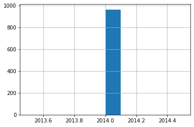

```python
import matplotlib as mp

DataFt['MODELYEAR'].hist()
```

### :سایز موتور

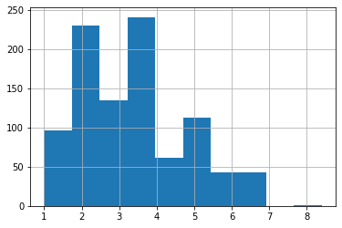

```python
DataFt['ENGINESIZE'].hist()
```

### :تعداد سیلندر

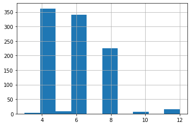

```python
DataFt['CYLINDERS'].hist()
```

### :مقدار مصرف سوخت در شهرها

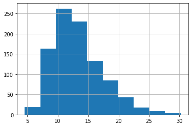

```python
DataFt['FUELCONSUMPTION_CITY'].hist()
```

### :مقدار مصرف سوخت در اتوبان ها

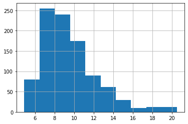

```python
DataFt['FUELCONSUMPTION_HWY'].hist()
```

### :مقدار مصرف سوخت ترکیبی(شهر و اتوبان)

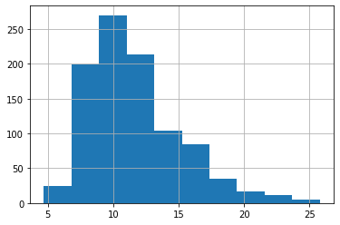

```python
DataFt['FUELCONSUMPTION_COMB'].hist()
```

### :مقدار مصرف سوخت ترکیبی در واحد مایل/گالن

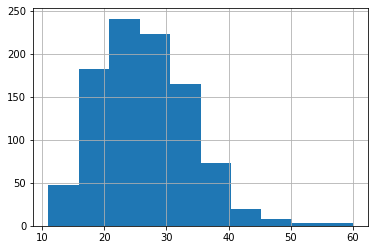

```python
DataFt['FUELCONSUMPTION_COMB_MPG'].hist()
```

### :مقدار کربن دی اکسید خروجی(هدف)

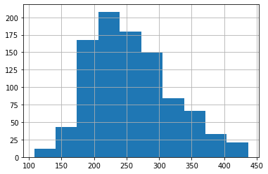

```python
DataFt['CO2EMISSIONS'].hist()
```

## بخش هفتم

#### نرمال سازی داده ها روشی است که داده هایی را که در یک دامنه نیستند در یک دانه مشابه قرار میدهد. بعضی از ویژگی های داده ها ممکن است در دامنه متفاوتی قرار داشته باشند که این تفاوت در مقیاس های زیاد باعث بوجود آمدن مشکلاتی می شود. برای جلوگیری از این مشکلات از نرمال سازی داده ها استفاده میکنیم. نرمال سازی داده ها روش های گوناگونی دارد که در این بخش ما ابتدا میانگین داده را از آن کم کرده و بر انحراف معیار تقسیم میکنیم که در زیر نشان دادیم

```python
DataFt['ENGINESIZE'] = (DataFt['ENGINESIZE'] - DataFt['ENGINESIZE'].mean())/DataFt['ENGINESIZE'].std()
DataFt['CYLINDERS'] = (DataFt['CYLINDERS'] - DataFt['CYLINDERS'].mean())/DataFt['CYLINDERS'].std()
DataFt['FUELCONSUMPTION_CITY'] = (DataFt['FUELCONSUMPTION_CITY'] - DataFt['FUELCONSUMPTION_CITY'].mean())/DataFt['FUELCONSUMPTION_CITY'].std()
DataFt['FUELCONSUMPTION_HWY'] = (DataFt['FUELCONSUMPTION_HWY'] - DataFt['FUELCONSUMPTION_HWY'].mean())/DataFt['FUELCONSUMPTION_HWY'].std()
DataFt['FUELCONSUMPTION_COMB'] = (DataFt['FUELCONSUMPTION_COMB'] - DataFt['FUELCONSUMPTION_COMB'].mean())/DataFt['FUELCONSUMPTION_COMB'].std()
DataFt['FUELCONSUMPTION_COMB_MPG'] = (DataFt['FUELCONSUMPTION_COMB_MPG'] - DataFt['FUELCONSUMPTION_COMB_MPG'].mean()) / DataFt['FUELCONSUMPTION_COMB_MPG'].std()
DataFt['CO2EMISSIONS'] = (DataFt['CO2EMISSIONS'] - DataFt['CO2EMISSIONS'].mean())/DataFt['CO2EMISSIONS'].std()

DataFt
```

|  | index | Unnamed: 0 | MODELYEAR | MAKE | MODEL | VEHICLECLASS | ENGINESIZE | CYLINDERS | TRANSMISSION | FUELTYPE | FUELCONSUMPTION_CITY | FUELCONSUMPTION_HWY | FUELCONSUMPTION_COMB | FUELCONSUMPTION_COMB_MPG | CO2EMISSIONS |
| --- | --- | --- | --- | --- | --- | --- | --- | --- | --- | --- | --- | --- | --- | --- | --- |
| 0 | 0 | 0 | 2014 | ACURA | ILX | COMPACT | -0.973622 | -1.024099 | AS5 | 0.0 | -0.833605 | -0.994870 | -0.888216 | 0.886286 | -0.960111 |
| 1 | 1 | 1 | 2014 | ACURA | ILX | COMPACT | -0.683744 | -1.024099 | M6 | 0.0 | -0.519842 | -0.641939 | -0.576247 | 0.352882 | -0.564949 |
| 2 | 2 | 2 | 2014 | ACURA | ILX HYBRID | COMPACT | -1.335970 | -1.024099 | AV7 | 0.0 | -1.774893 | -1.312508 | -1.625596 | 2.886552 | -1.908498 |
| 3 | 4 | 4 | 2014 | ACURA | RDX AWD | SUV - SMALL | 0.113422 | 0.100355 | AS6 | 0.0 | -0.302621 | -0.289008 | -0.292640 | 0.086180 | -0.201401 |
| 4 | 5 | 5 | 2014 | ACURA | RLX | MID-SIZE | 0.113422 | 0.100355 | AS6 | 0.0 | -0.350893 | -0.641939 | -0.462804 | 0.219531 | -0.422691 |
| ... | ... | ... | ... | ... | ... | ... | ... | ... | ... | ... | ... | ... | ... | ... | ... |
| 959 | 1062 | 1062 | 2014 | VOLVO | XC60 AWD | SUV - SMALL | -0.248926 | 0.100355 | AS6 | 3.0 | 0.011141 | 0.099216 | 0.047690 | -0.313873 | 0.225373 |
| 960 | 1063 | 1063 | 2014 | VOLVO | XC60 AWD | SUV - SMALL | -0.103987 | 0.100355 | AS6 | 3.0 | -0.037130 | -0.006663 | -0.037393 | -0.180522 | 0.114728 |
| 961 | 1064 | 1064 | 2014 | VOLVO | XC70 AWD | SUV - SMALL | -0.248926 | 0.100355 | AS6 | 3.0 | 0.011141 | 0.099216 | 0.047690 | -0.313873 | 0.225373 |
| 962 | 1065 | 1065 | 2014 | VOLVO | XC70 AWD | SUV - SMALL | -0.103987 | 0.100355 | AS6 | 3.0 | -0.109537 | -0.077249 | -0.094114 | -0.180522 | 0.051502 |
| 963 | 1066 | 1066 | 2014 | VOLVO | XC90 AWD | SUV - STANDARD | -0.103987 | 0.100355 | AS6 | 3.0 | 0.373175 | 0.240388 | 0.331297 | -0.580575 | 0.588921 |

964 rows × 15 columns

## بخش هشتم

### در زیر نمودار های خواسته شده برای هر ویژگی را رسم کردیم

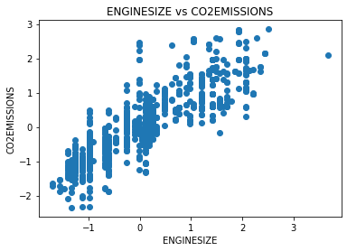

```python
import matplotlib.pyplot as plt

plt.scatter(DataFt['ENGINESIZE'], DataFt['CO2EMISSIONS'])
plt.title("ENGINESIZE vs CO2EMISSIONS")
plt.ylabel("CO2EMISSIONS")
plt.xlabel("ENGINESIZE")
plt.show()
```

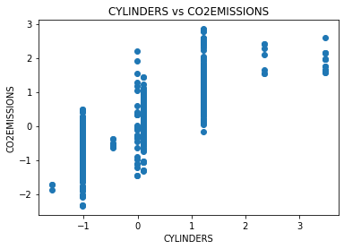

```python
plt.scatter(DataFt['CYLINDERS'], DataFt['CO2EMISSIONS'])
plt.title("CYLINDERS vs CO2EMISSIONS")
plt.ylabel("CO2EMISSIONS")
plt.xlabel("CYLINDERS")
plt.show()
```

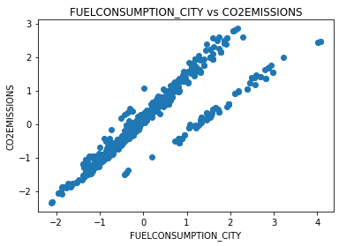

```python
plt.scatter(DataFt['FUELCONSUMPTION_CITY'], DataFt['CO2EMISSIONS'])
plt.title("FUELCONSUMPTION_CITY vs CO2EMISSIONS")
plt.ylabel("CO2EMISSIONS")
plt.xlabel("FUELCONSUMPTION_CITY")
plt.show()
```

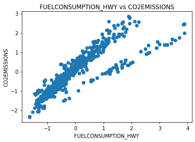

```python
plt.scatter(DataFt['FUELCONSUMPTION_HWY'], DataFt['CO2EMISSIONS'])
plt.title("FUELCONSUMPTION_HWY vs CO2EMISSIONS")
plt.ylabel("CO2EMISSIONS")
plt.xlabel("FUELCONSUMPTION_HWY")
plt.show()
```

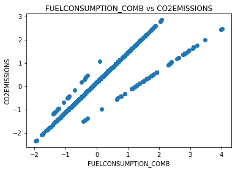

```python
plt.scatter(DataFt['FUELCONSUMPTION_COMB'], DataFt['CO2EMISSIONS'])
plt.title("FUELCONSUMPTION_COMB vs CO2EMISSIONS")
plt.ylabel("CO2EMISSIONS")
plt.xlabel("FUELCONSUMPTION_COMB")
plt.show()
```

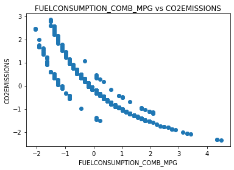

```python
plt.scatter(DataFt['FUELCONSUMPTION_COMB_MPG'], DataFt['CO2EMISSIONS'])
plt.title("FUELCONSUMPTION_COMB_MPG vs CO2EMISSIONS")
plt.ylabel("CO2EMISSIONS")
plt.xlabel("FUELCONSUMPTION_COMB_MPG")
plt.show()
```

#### طبق نمودارها به نظر میرسد که مقدار مصرف سوخت ترکیبی در واحد مایل/گالن بیشترین هم بستگی را داشته باشد حال انتخاب خود را توجیه میکنیم

#### برای به دست آوردن ویژگی با بیشترین میزان همبستگی با مقدار کربن دی اکسید خروجی از ماتریس همبستگی استفاده میکنیم. اگر یک ویژگی دارای هم بستگی نزدیک 1 یا 1- باشد خطی تر از سایر ویژگی ها است. همانطور که مشاهده میکنید بیشترین همبستگی را ویژگی مقدار مصرف سوخت ترکیبی در واحد مایل/گالن و هم بستگی آن نزدیک به 1- است.

```python
DataFt.corr()['CO2EMISSIONS'].sort_values()
```

```
FUELCONSUMPTION_COMB_MPG   -0.905606
index                      -0.189839
Unnamed: 0                 -0.189839
FUELTYPE                   -0.176800
CYLINDERS                   0.836442
FUELCONSUMPTION_HWY         0.858261
ENGINESIZE                  0.859528
FUELCONSUMPTION_COMB        0.888687
FUELCONSUMPTION_CITY        0.894860
CO2EMISSIONS                1.000000
MODELYEAR                        NaN
Name: CO2EMISSIONS, dtype: float64
```

## بخش نهم

```python
DataF9 = DataFt[['FUELCONSUMPTION_COMB_MPG', 'CO2EMISSIONS']]
DataF9
```

|  | FUELCONSUMPTION_COMB_MPG | CO2EMISSIONS |
| --- | --- | --- |
| 0 | 0.886286 | -0.960111 |
| 1 | 0.352882 | -0.564949 |
| 2 | 2.886552 | -1.908498 |
| 3 | 0.086180 | -0.201401 |
| 4 | 0.219531 | -0.422691 |
| ... | ... | ... |
| 959 | -0.313873 | 0.225373 |
| 960 | -0.180522 | 0.114728 |
| 961 | -0.313873 | 0.225373 |
| 962 | -0.180522 | 0.051502 |
| 963 | -0.580575 | 0.588921 |

964 rows × 2 columns

## بخش دهم

#### را تعریف میکنیم ht تابع

```python
def htprd(t1 , t0, x):
    out = [t1*i + t0 for i in x]
    return out
```

#### را تعریف میکنیم mse تابع

```python
def mse(yi, ht):
    n = len(yi)
    pw = sum(pow((yi - ht), 2))
    s = pw / n
    return s
```

```python
def slin(data):

    C=[]
    C = np.full((len(data['FUELCONSUMPTION_COMB_MPG']),1),1)

    X = np.column_stack((C,data['FUELCONSUMPTION_COMB_MPG']))
    Xt = X.transpose()

    xtx = np.dot(Xt, X)
    xtxi = np.linalg.inv(xtx)

    xty = np.dot(Xt,  data['CO2EMISSIONS'])

    cal = np.dot(xtxi, xty)
    return cal

cal = slin(DataF9)
intercept = cal[0]
slope = cal[1]
```

```python
yi = htprd(slope , intercept, DataF9['FUELCONSUMPTION_COMB_MPG'])
```

#### بعد از تعریف توابع حال درصد خطای تابع تخمین گر را با داده هایی که هدفشان مشخص است چک میکنیم

```python
error = mse(yi, (DataF9['CO2EMISSIONS']))
print(error)
```

```
0.17969142412250538
```

#### کم تر از 0.5 شد mse همانطور که میبینید خروجی تابع

## بخش یازدهم

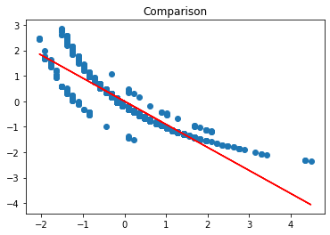

```python
plt.scatter(DataF9['FUELCONSUMPTION_COMB_MPG'], DataF9['CO2EMISSIONS'])
plt.title("Comparison")
plt.plot(DataF9['FUELCONSUMPTION_COMB_MPG'], yi, c = 'r')
plt.show()
```

#### همانطور که در شکل بالا مشاهده میکنید به طور متوسط نمودار تخمین گر بر نمودار مقدار مصرف سوخت ترکیبی در واحد مایل/گالن منطبق است ولی در همه ی نمودار اینگونه نیست و حدودی نمودار را میپوشاند

## بخش دوازدهم

#### خطای کپی را حذف میکنیم warning با استفاده از تابع

```python
import warnings
warnings.filterwarnings('ignore')

DataFt1 = DataF.dropna(subset = ['CO2EMISSIONS'])
DataFt1 = DataFt1.reset_index()

n_DataFn = (n_DataF['FUELCONSUMPTION_COMB_MPG']-n_DataF['FUELCONSUMPTION_COMB_MPG'].mean())/n_DataF['FUELCONSUMPTION_COMB_MPG'].std()
predicted = htprd(slope , intercept, n_DataFn)
n_DataF.loc[:, 'CO2EMISSIONS'] = predicted

n_DataF.loc[:, 'CO2EMISSIONS'] = n_DataF['CO2EMISSIONS']*DataFt1['CO2EMISSIONS'].std() + DataFt1['CO2EMISSIONS'].mean()
print(n_DataF)
```

```
      Unnamed: 0  MODELYEAR        MAKE                MODEL    VEHICLECLASS  \
3              3       2014       ACURA              MDX 4WD     SUV - SMALL
20            20       2014        AUDI           A4 QUATTRO         COMPACT
30            30       2014        AUDI                   A8        MID-SIZE
42            42       2014        AUDI                   Q7  SUV - STANDARD
43            43       2014        AUDI  Q7 TDI CLEAN DIESEL  SUV - STANDARD
...          ...        ...         ...                  ...             ...
1022        1022       2014  VOLKSWAGEN   BEETLE CONVERTIBLE      SUBCOMPACT
1027        1027       2014  VOLKSWAGEN                   CC         COMPACT
1051        1051       2014  VOLKSWAGEN               TIGUAN     SUV - SMALL
1052        1052       2014  VOLKSWAGEN               TIGUAN     SUV - SMALL
1053        1053       2014  VOLKSWAGEN       TIGUAN 4MOTION     SUV - SMALL

      ENGINESIZE  CYLINDERS TRANSMISSION  FUELTYPE  FUELCONSUMPTION_CITY  \
3            3.5   6.000000          AS6   0.00000                  12.7
```

[output cut: 38 more lines]

#### چون در قسمت سوم نرمال سازی نکرده بودیم داده ها را نرمال سازی کرده و به تابع تخمین گر میدهیم و سپس در نهایت دوباره به حالت اول خود برمیگردانیم

```python
n_DataF.to_csv('result.csv')
```

#### در انتها داده ها را در یک فایل جدید ذخیره میکنیم. در مواجهه با مسائل و داده های واقعی ممکن است خیلی از پارامتر ها ناموجود باشند که برای به دست آوردن دقیق تر نتیجه ی تحقیقات باید به درستی آن ها را مشخص کرد. در این پروژه ما به وسیله ی توابع و روش هایی داده های نامشخصمان را پیش بینی کرده و جایگزینشان کردیم